# Bellaire City Council: local ideal points, 2004–2026

Texas · Preliminary pooled analysis

Author

Boris Shor

Updated

October 26, 2026

Bellaire’s divided council votes place **Pat McLaughlan** alone at one end of the scale (-3.31) and **Catherine Lewis** (2.30), **Jim Hotze** (1.78) and **Will Hickman** (1.54) together at the other. The remaining 21 members sit in a compressed middle between -0.66 and 0.49, with Cindy Cohen Taylor (-1.19, 28 votes) the only other clearly negative position. Party evidence is only weakly related to this ordering: three people have documented Republican evidence, but **Cynthia Siegel**, mayor from 2004 to 2012, sits near zero (0.03), and the highest-scoring member has no documented party at all. These are voting positions within Bellaire, not scores on a national ideological scale.

**26 officials** Including four mayors

**784 divided votes** 354 with a one-member minority

**5,134 responses** Recorded yeas and nays

**Eleven council windows** 2004–2006 through 2024–2026

## Dataset and construction

The analysis uses **published roll call votes** extracted from Bellaire’s official council minutes in the October 26, 2026 package (release 2026-10-26b), a machine-built candidate dataset that has not been independently approved. The minutes come from the city’s Archive Center (2003–2013), its IQM2 meeting portal (2010–2018) and its CivicWeb portal (2015–2026). The package covers January 2003 through October 2026. Minutes through mid-2004 print only vote tallies, without names, so the fitted events run from **September 13, 2004 to July 6, 2026**. This is a sample of recoverable divided votes, not every council decision.

Bellaire’s council is six members plus the mayor, and the mayor votes with the council. Elections are nonpartisan. The city’s canvass records show regular council elections in November of odd years, with terms beginning the following January, plus special elections and runoffs. The tabs below follow those **two-year elected councils**, from 2004–2006 to 2024–2026. Each starts in the January after an election, and the seat records show turnover at those dates from 2006 through 2024. The November 2025 election returned the mayor and all three council incumbents on the ballot. The council seated in January 2026 therefore differs from its predecessor only by Cindy Cohen Taylor’s departure and Todd Thurber’s May 2026 special-election win. Its few 2026 votes are shown with the 2024–2026 tab. Mid-term replacements are included where observed.

We keep a vote when at least one member is on each side and at least five members have identified yea/nay responses; officials need at least seven such responses, and both screens repeat until stable. **Votes with a one-member minority are retained** (354 of 784), as are all procedural motions that were divided. Unanimous votes, absences, abstentions, recusals and unreadable entries do not enter the likelihood. Package reprints of the same minutes are counted once. Todd Thurber (two divided votes) falls below the member threshold and is not fitted.

| Council | Mayor | Officials | Divided events | Yea/nay responses |
| --- | --- | --- | --- | --- |
| 2004–2006 | Cynthia Siegel | 7 | 33 | 213 |
| 2006–2008 | Cynthia Siegel | 7 | 100 | 624 |
| 2008–2010 | Cynthia Siegel | 8 | 106 | 652 |
| 2010–2012 | Cynthia Siegel | 8 | 105 | 695 |
| 2012–2014 | Philip L. Nauert | 7 | 108 | 719 |
| 2014–2016 | Philip L. Nauert | 8 | 87 | 571 |
| 2016–2018 | Andrew S. Friedberg | 7 | 90 | 613 |
| 2018–2020 | Andrew S. Friedberg | 7 | 36 | 245 |
| 2020–2022 | Andrew S. Friedberg | 7 | 52 | 357 |
| 2022–2024 | Andrew S. Friedberg | 7 | 28 | 187 |
| 2024–2026 | Gus E. Pappas | 7 | 39 | 258 |

Coverage is uneven. Retained events run at 42–63 a year from 2006 through 2017 and at 5–31 a year after, partly because the source mix changes and partly because 61 listed meetings, mostly in 2014–2018, have no minutes in the package. A bounded October 23 check of 14 sampled votes in earlier Bellaire minutes matched all 98 printed responses. The check supports those sampled records, not a corpus-wide error rate. See the technical appendix for the audit and model details.

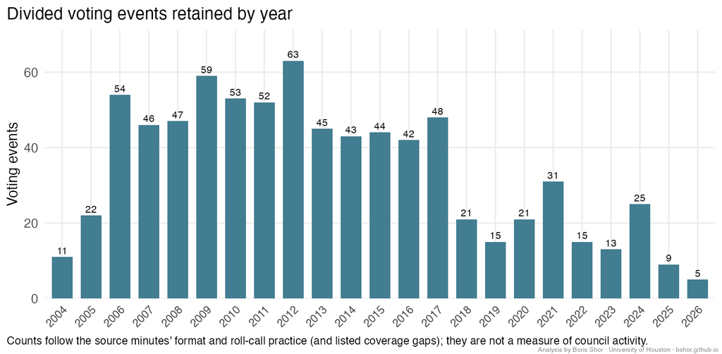

Retained divided voting events by year. Coverage varies with the source minutes and roll-call practice.

## Voting positions

McLaughlan is at -3.31, Lewis at 2.30, Hotze at 1.78 and Hickman at 1.54. McLaughlan’s long tail is a consequence of casting many lone or near-lone negative votes, and his interval is by far the widest, so his exact distance from the others is imprecise. Between these poles the members are tightly packed: 21 people lie within 1.15 units of each other, which is small compared with the intervals on several of the end positions. Longer horizontal lines indicate less precise placements. Gray members have no supported party label; their position does not assign them one.

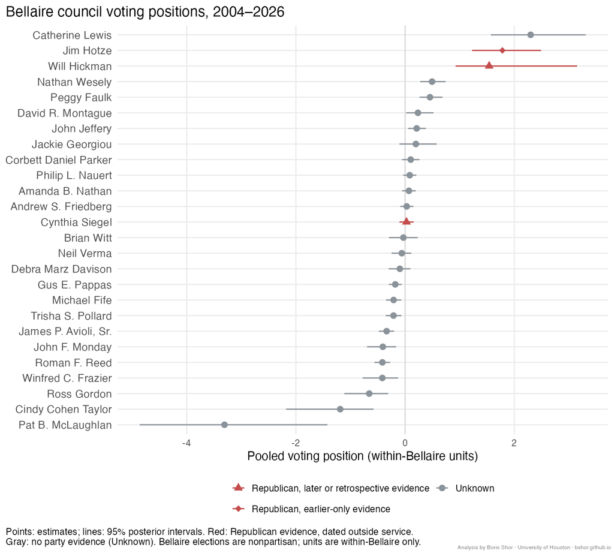

Twenty-six Bellaire officials ordered by pooled voting position with 95 percent posterior intervals; red marks show dated Republican evidence, gray marks Unknown.

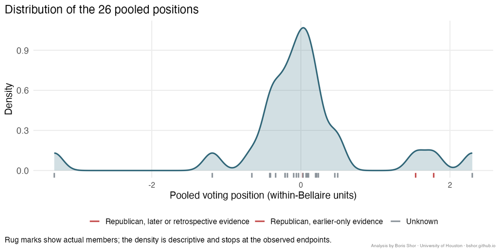

Overall density of 26 member estimates with colored rug marks showing actual observed members.

### Elected councils

Each tab shows the same pooled member scores, restricted to officials observed in that council window. This makes turnover visible without treating each panel as a separate estimate of changing individual ideology. Every member has one static position across all observed service.

**2004–2006**

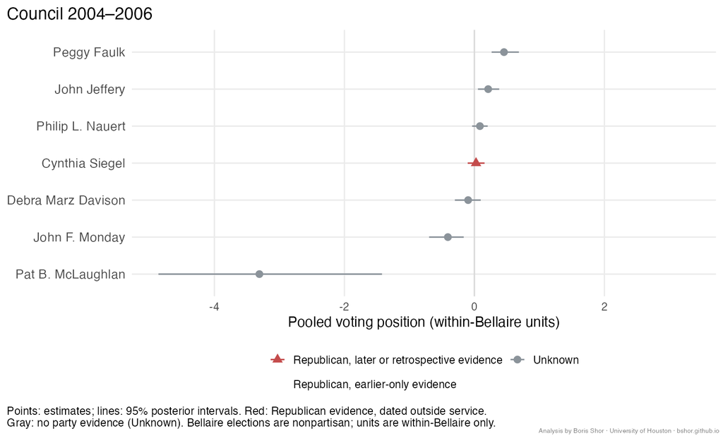

7 fitted officials observed in the 2004–2006 council window (33 divided events); mayor Cynthia Siegel. Pooled-scale positions.

**2006–2008**

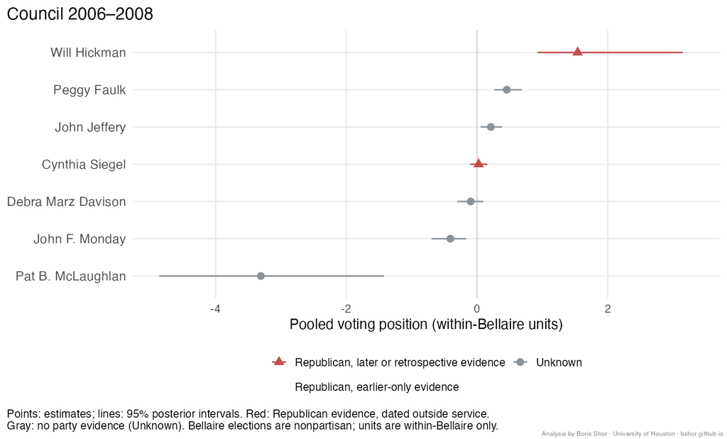

7 fitted officials observed in the 2006–2008 council window (100 divided events); mayor Cynthia Siegel. Pooled-scale positions.

**2008–2010**

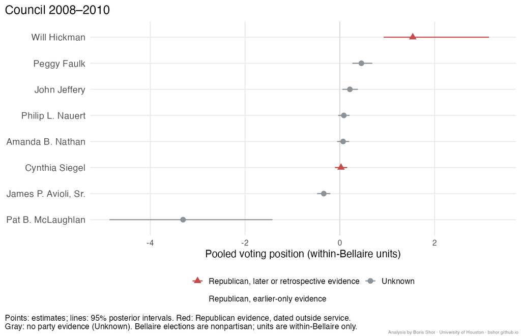

8 fitted officials observed in the 2008–2010 council window (106 divided events); mayor Cynthia Siegel. Pooled-scale positions.

**2010–2012**

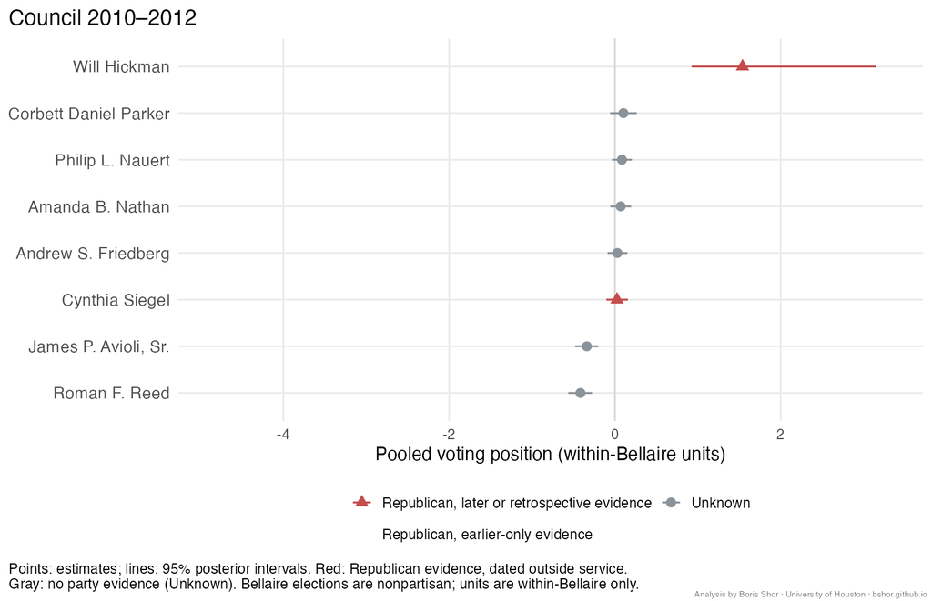

8 fitted officials observed in the 2010–2012 council window (105 divided events); mayor Cynthia Siegel. Pooled-scale positions.

**2012–2014**

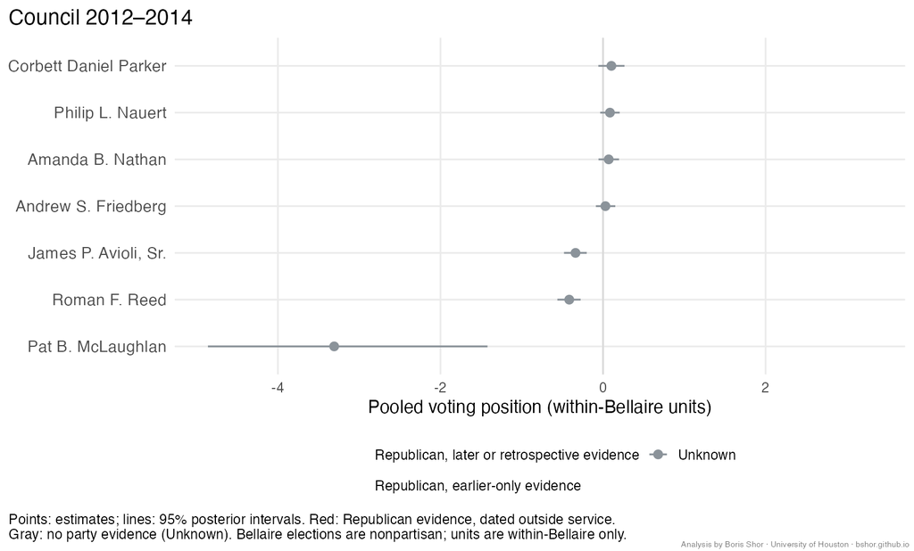

7 fitted officials observed in the 2012–2014 council window (108 divided events); mayor Philip L. Nauert. Pooled-scale positions.

**2014–2016**

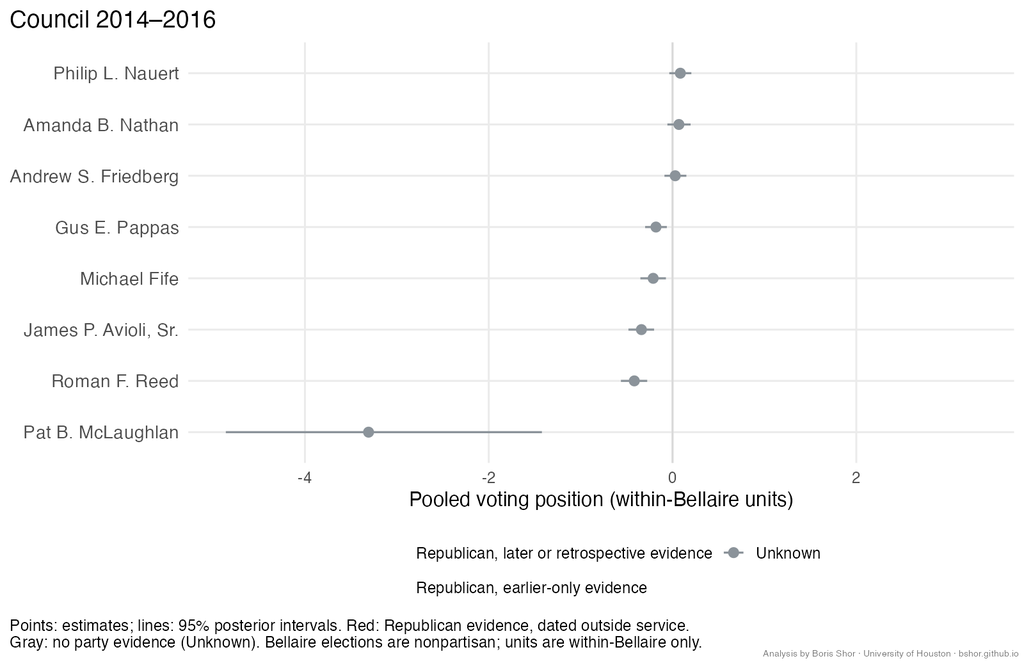

8 fitted officials observed in the 2014–2016 council window (87 divided events); mayor Philip L. Nauert. Pooled-scale positions.

**2016–2018**

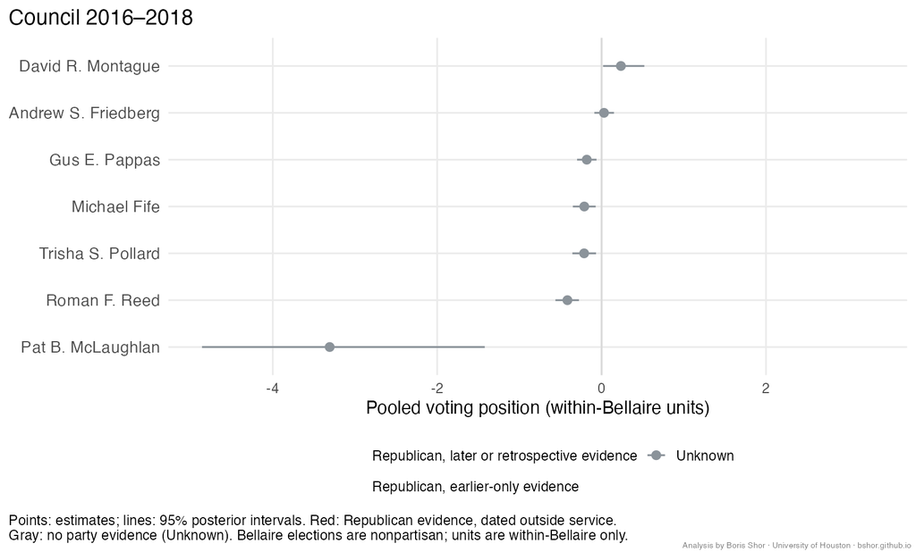

7 fitted officials observed in the 2016–2018 council window (90 divided events); mayor Andrew S. Friedberg. Pooled-scale positions.

**2018–2020**

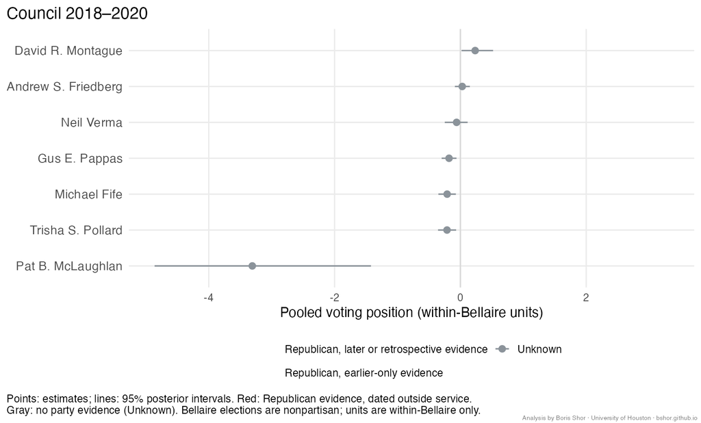

7 fitted officials observed in the 2018–2020 council window (36 divided events); mayor Andrew S. Friedberg. Pooled-scale positions.

**2020–2022**

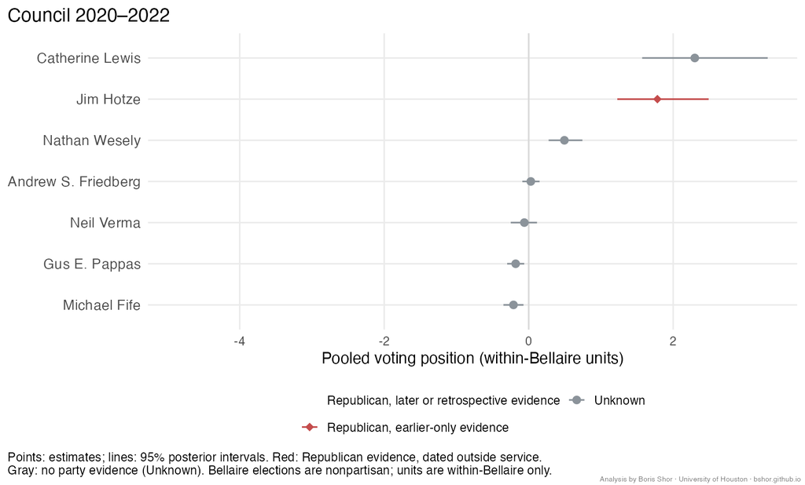

7 fitted officials observed in the 2020–2022 council window (52 divided events); mayor Andrew S. Friedberg. Pooled-scale positions.

**2022–2024**

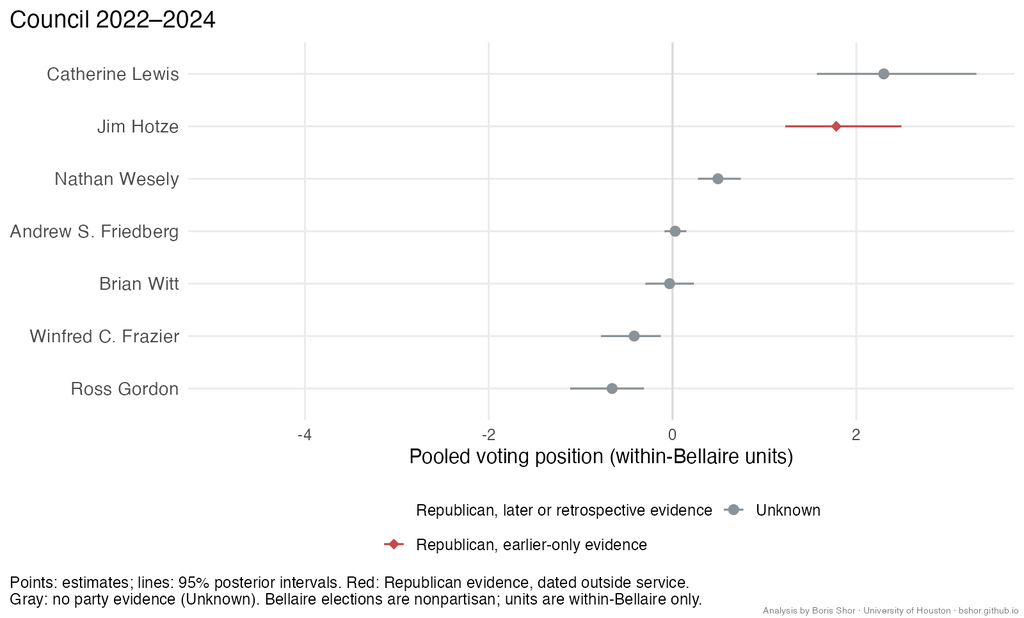

7 fitted officials observed in the 2022–2024 council window (28 divided events); mayor Andrew S. Friedberg. Pooled-scale positions.

**2024–2026**

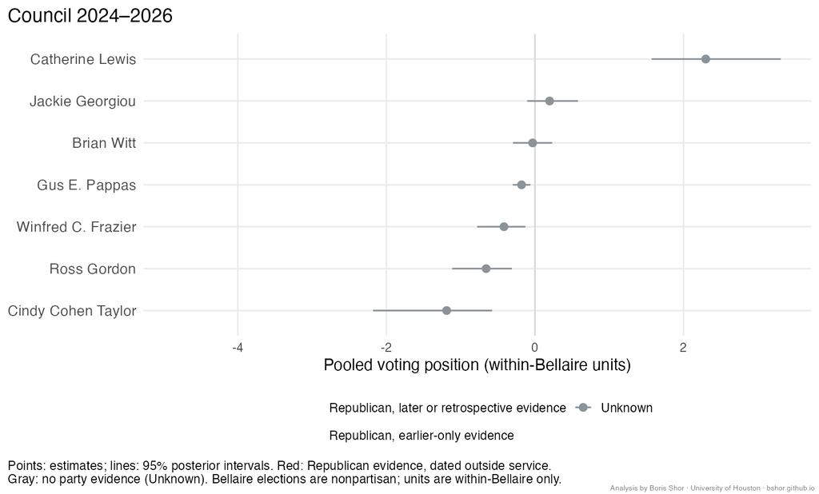

7 fitted officials observed in the 2024–2026 council window (39 divided events); mayor Gus E. Pappas. Pooled-scale positions.

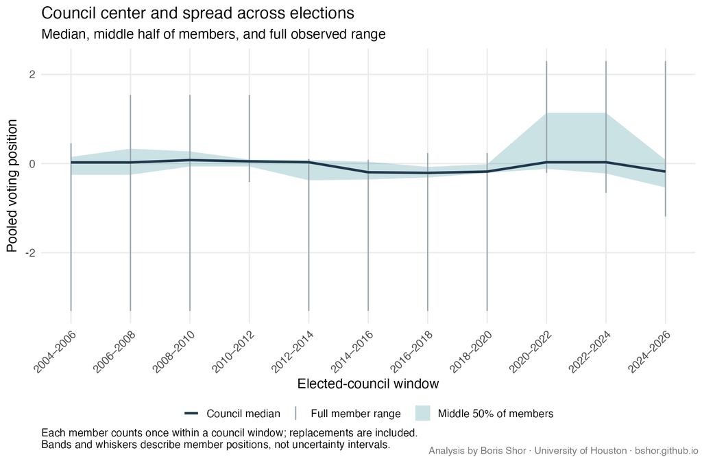

Median, middle half and full range of member positions in each council window; bands describe members, not uncertainty.

## Party evidence and alignment

Bellaire’s elections are nonpartisan and Texas has no party registration, so affiliations come from independent public records and reporting, not from council voting. **Only three of 26 fitted officials have any Republican evidence, and the other 23 are Unknown after research; there is no documented Democratic affiliation.** Each label carries a time limit:

- **Siegel**: Harris County Republican Party chair (elected December 2020) and a 2020 Republican congressional primary candidate. This evidence is later than her 2004–2012 mayoralty.
- **Hickman**: described as Republican in a Texas Education Agency State Board of Education candidate biography; the reference is retrospective and undated, and the identity match is moderately supported.
- **Hotze**: listed as a Republican precinct-chair candidate in the official March 2014 Harris County primary, six years before his 2020–2023 council service. This evidence is earlier only.

None of these establishes a party label during service, and none implies a party for any Unknown member.

| Group | Members | Median position | Range |
| --- | --- | --- | --- |
| Unknown | 23 | -0.06 | -3.31 to 2.30 |
| Republican evidence | 3 | 1.54 | 0.03 to 1.78 |
| Republican, later or retrospective evidence (Siegel, Hickman) | 2 | 0.78 | 0.03 to 1.54 |
| Republican, earlier-only evidence (Hotze) | 1 | 1.78 | 1.78 to 1.78 |

The median position of the three Republican-evidence members (1.54) is 1.60 above the median of the 23 Unknown members (-0.06). That difference is almost entirely Hickman’s and Hotze’s positions: Siegel sits at 0.03, effectively at the Unknown median, and Lewis, with no documented party, is further positive than any of the three. With three labeled people, mostly dated outside their service, the comparison is descriptive and does not show that party explains the Bellaire scale.

[output not shown]

Only the council windows in which a Republican-evidence member served are shown; no window contains more than two.

## The mayors

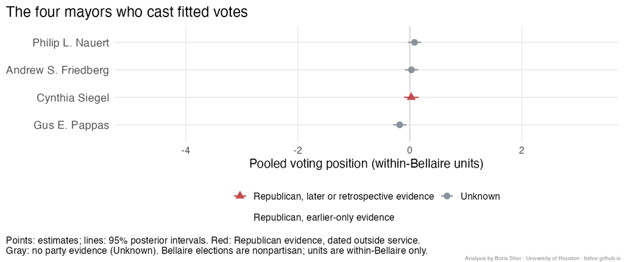

Pooled positions of the four mayors, including their votes in other council roles.

## What the divisions concern

Topics come from a separate supervised machine coding of the (often truncated) motion text. They are descriptive, are not a model input, and 47 of the 784 codes are low confidence. Motions to postpone, table or close debate are counted under governance and procedure, whatever matter they concern.

| Topic | Divided events | Share |
| --- | --- | --- |
| land use zoning | 171 | 22% |
| governance procedure | 154 | 20% |
| budget tax | 120 | 15% |
| infrastructure | 112 | 14% |
| contracts spending | 80 | 10% |
| ordinances regulation | 62 | 8% |
| other | 51 | 7% |
| appointments | 34 | 4% |

The table compares nay shares on each topic for McLaughlan, the positive pole (Lewis, Hotze and Hickman) and the other members. Cell sizes are shown because some topics are small.

| Topic | Events | McLaughlan votes | McLaughlan nay | Pole votes | Pole nay | Others nay |
| --- | --- | --- | --- | --- | --- | --- |
| land use zoning | 171 | 92 | 41% | 127 | 36% | 41% |
| governance procedure | 154 | 114 | 49% | 74 | 35% | 38% |
| budget tax | 120 | 96 | 47% | 55 | 45% | 39% |
| infrastructure | 112 | 89 | 51% | 69 | 41% | 37% |
| contracts spending | 80 | 61 | 44% | 34 | 44% | 25% |
| ordinances regulation | 62 | 45 | 36% | 34 | 32% | 44% |
| other | 51 | 40 | 45% | 33 | 45% | 29% |
| appointments | 34 | 17 | 41% | 28 | 29% | 28% |

Nay shares are broadly similar across topics: McLaughlan votes nay on 36% to 51% of divided votes in every topic, and the pole on 29% to 45%. The clearest gap is **contracts and spending**, where McLaughlan (44%) and the pole (44%) dissent far more often than other members (25%); the pole figure rests on only 34 votes. The data do not show a single topic that sorts the poles from the rest.

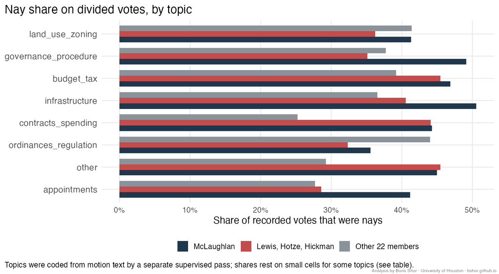

Share of recorded votes that were nays by topic, for McLaughlan, the positive pole and other members.

Two examples show what a divided vote looks like.

**A financial-advisory contract, July 1, 2013.** In the [July 1, 2013 minutes](https://www.bellairetx.gov/ArchiveCenter/ViewFile/Item/3503), council voted on an ordinance authorizing a contract with USCA Municipal Advisors LLC for municipal finance consulting. It carried 5–1. Mayor Nauert and Councilmen Reed, Avioli, Parker and Friedberg voted for it; McLaughlan was the lone opponent, and Mayor Pro Tem Nathan was absent. The supervised coding classes it as budget and tax; it is one of many lone McLaughlan dissents.

**A zoning amendment, May 24, 2021.** In the [May 24, 2021 minutes](https://bellairetx.civicweb.net/document/42590), Amendment 10A would have changed a proposed green-space buffer from “65 feet” to “45 feet” in a zoning rewrite (coded land use and zoning). It failed 2–5: Mayor Friedberg and Mayor Pro Tem Pappas voted for it, while Verma, Lewis, Wesely, Fife and Hotze voted against. Lewis and Hotze are the two positive-pole members, and they were on the same side as three members who sit near the middle.

The scale summarizes coalitions across hundreds of such decisions, not a judgment that every negative vote has the same ideological meaning.